# R Notebook

Good Morning:

This is your daily COVID-19 report, sent on Friday, January 15, 2021 at 6:04 AM (PST). Shown below is a current **draft** in continual development and error checking. Please feel free to reach out with suggestions or issues! Click here to review the [interactive report](https://jensennhu.github.io/covid_sitrep_auto_prod/). If you’re curious about the situation in other places in the USA (state/county level) or international locations, please click [**here**](http://ec2-3-17-139-199.us-east-2.compute.amazonaws.com:3838/shiny_covid19_aws/).

### USA Overall

> As of yesterday, there has been a total of 23,133,918 cases of COVID-19 in the USA. This is a change of 230,476 (1.01%) new cases since the day prior. The 7 day moving average is currently 2.354e+05 new cases which is a -0.69% change since the day prior and 0.95% change since the week prior. The immediate trend is heading upward. Based on the addition of yesterday’s data, yesterday was not an inflection point (days since last inflection point: 13 –> 2021-01-01).

#### 7-day moving average of new cases in the US (2020-01-21 to 2021-01-13)

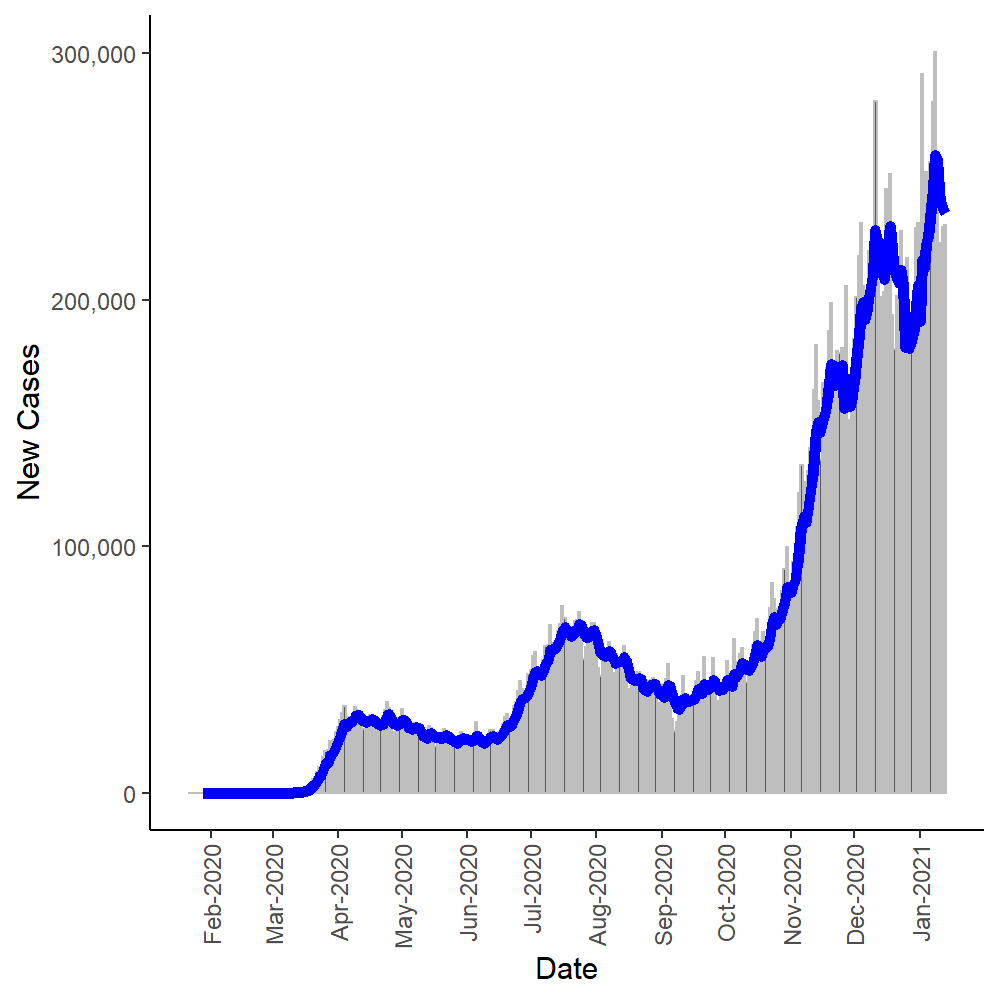

### State Consecutive Day Trends

> Of the 51 US states monitored, **17 (33.33%)** show consecutive increase in their 7-day moving average of new COVID-19 cases for at least 7 days. **0 (0%)** show consecutive decrease for at least 7 days.

#### **17** State(s) with Consecutive Increase for at least 7 days

[output not shown]

#### **0** State(s) with Consecutive Decrease for at least 7 days

| State | Cases per 100,000 | Consecutive Days |
| --- | --- | --- |

### Hospital Status (Beta)

> On average, the current stress on ICUs across the country is *extreme*. Stress definitions can be found below:
- **low**: less than 10% of ICU Usage
- **moderate**: 10-29% of ICU Usage
- **high**: 30-59% of ICU Usage
- **extreme**: greater than 60% of ICU Usage

[figure not shown]

### Region by Region

How to read the maps below:

- **Cases Higher**: greater than or equal to 15 new cases per 100,000 people.
- **Cases Lower**: less than 15 new cases per 100,000 people.
- **Rising**: increase in the 7-day moving average, week over week.
- **Decreasing**: decrease in the 7-day moving average, week over week.
- **Staying**: no change in the 7-day moving average, week over weeks

#### **Western US**

[figure not shown]

#### **Southern US**

[figure not shown]

#### **Midwestern US**

[figure not shown]

#### **Northeastern US**

[figure not shown]

### Other resources

Other resources to check out:

- [See How All 50 States Are Reopening (and Closing Again)](https://www.nytimes.com/interactive/2020/us/states-reopen-map-coronavirus.html)
- [NYtimes Visualizations for Case Tracking in U.S.](https://www.nytimes.com/interactive/2020/us/coronavirus-us-cases.html)
- [Coronavirus Drug and Treatment Tracker](https://www.nytimes.com/interactive/2020/science/coronavirus-drugs-treatments.html)
- [Coronavirus Vaccine Tracker](https://www.nytimes.com/interactive/2020/science/coronavirus-vaccine-tracker.html)
- [US Projections](https://covid19.healthdata.org/united-states-of-america?view=total-deaths&tab=trend)

## A closer look at your area(s) of interest:

### New York, USA

> As of yesterday, there has been a total of 1,179,523 cases of COVID-19 in New York. This is a change of 14,704 (1.26%) new cases since the day prior. The 7 day moving average is currently 1.536e+04 new cases which is a -1.41% change since the day prior and 11.2% change since the week prior. The immediate trend is heading upward. Based on the addition of yesterday’s data, yesterday was not an inflection point (days since last inflection point: 89 –> 2020-10-17).

#### 7-day moving average of new cases in New York (2020-03-01 to 2021-01-13)

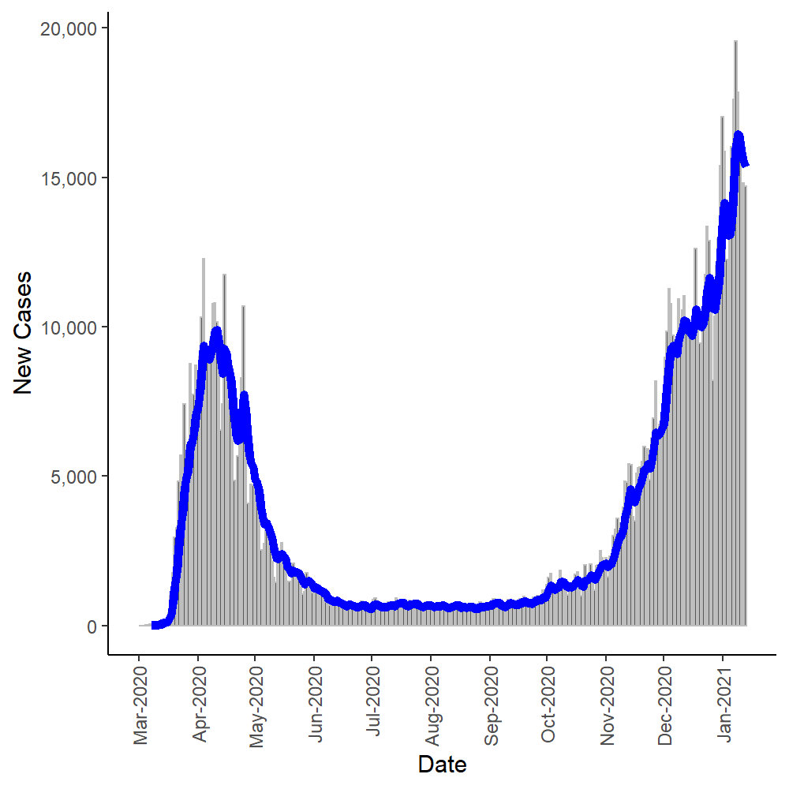

### New York City, NY

> As of yesterday, there has been a total of 504,826 cases of COVID-19 in New York City County, New York. This is a change of 5,949 (1.19%) new cases since the day prior. The 7 day moving average is currently 5,891 new cases which is a 0.33% change since the day prior and 22.55% change since the week prior. The immediate trend is heading upward. Based on the addition of yesterday’s data, yesterday was not an inflection point (days since last inflection point: 24 –> 2020-12-21).

#### 7-day moving average of new cases in New York City (2020-03-01 to 2021-01-13)

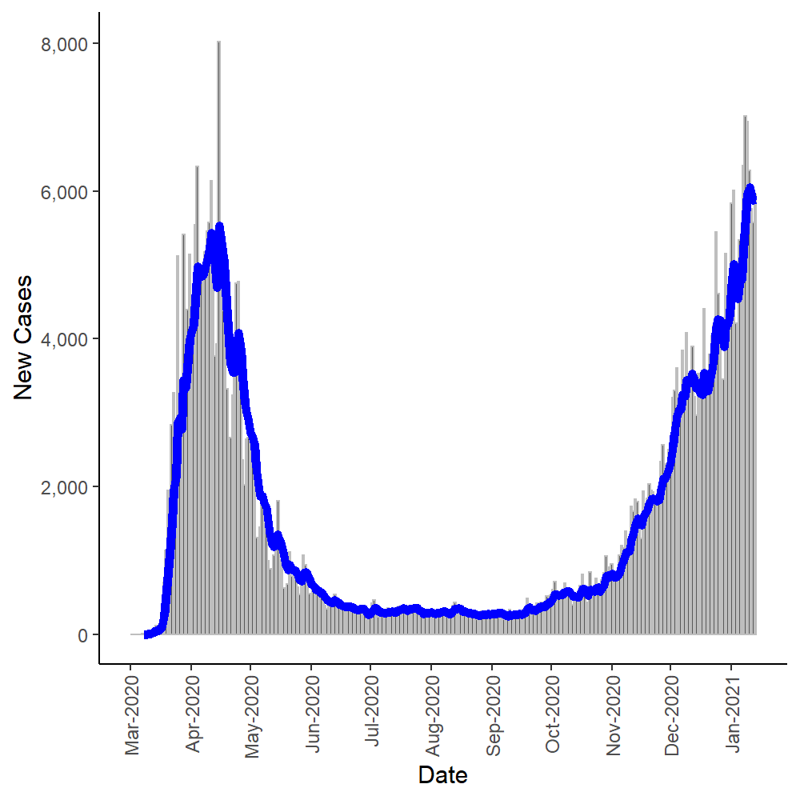

### Virginia, USA

> As of yesterday, there has been a total of 412,545 cases of COVID-19 in Virginia. This is a change of 4,598 (1.13%) new cases since the day prior. The 7 day moving average is currently 4,803 new cases which is a -1.4% change since the day prior and 5.03% change since the week prior. The immediate trend is heading upward. Based on the addition of yesterday’s data, yesterday was not an inflection point (days since last inflection point: 13 –> 2021-01-01).

#### 7-day moving average of new cases in Virginia (2020-03-07 to 2021-01-13)

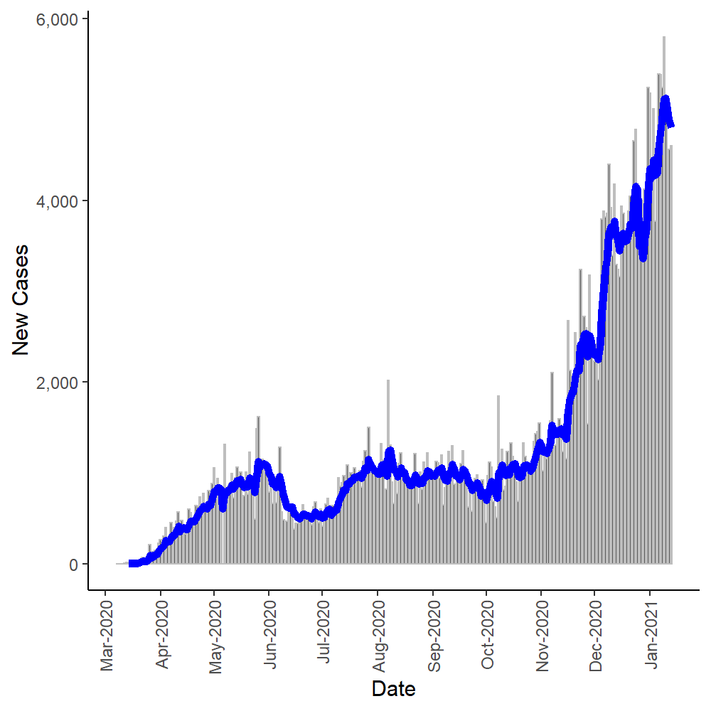

### Virginia Beach City, VA

> As of yesterday, there has been a total of 21,133 cases of COVID-19 in Virginia Beach city County, Virginia. This is a change of 354 (1.7%) new cases since the day prior. The 7 day moving average is currently 359.9 new cases which is a -0.54% change since the day prior and 24.98% change since the week prior. The immediate trend is heading upward. Based on the addition of yesterday’s data, yesterday was not an inflection point (days since last inflection point: 25 –> 2020-12-20).

#### 7-day moving average of new cases in Virginia Beach City (County), VA (2020-03-09 to 2021-01-13)

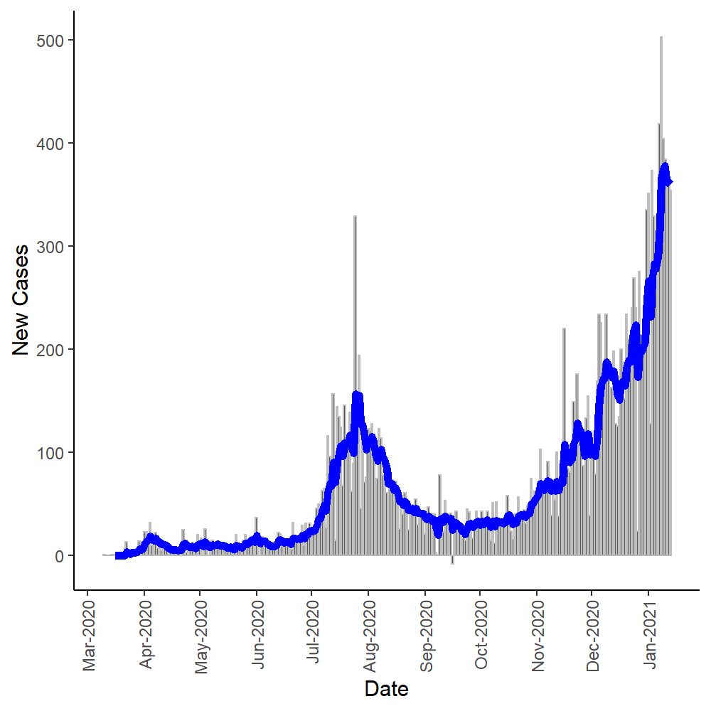